# Equipo

### Dylan Craven, Investigador Principal

[figure not shown]

### María del Pilar Fernández Murillo, estudiante de doctorado (Universidad Mayor)

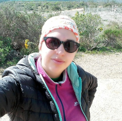

Ecológa, Universidad de La Serena  
Pili es una ecóloga cuya investigación se enfoca en responder cómo la pérdida de biodiversidad, en especial la pérdida de herbívoros, puede modificar en múltiples escalas el funcionamiento de las plantas efímeras en los ecosistemas semiáridos. Apuesta mucho a la difusión de la ciencia como una herramienta para futuros cambios, por ello también es un miembro activo de la Organización [ECOTERRA](https://ongecoterra.org/).

### Fiorella Gonzales Guillén, estudiante de doctorado (Pontificia Universidad Católica de Chile)

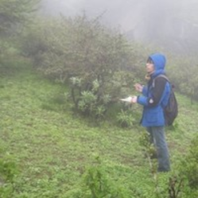

Ecológa  
Fiorella es ecóloga y en su doctorado examina los patrones e impulsores de la diversidad de las lomas costeras de Perú y Chile.

### Valentina Pérez, Asistente de Investigación

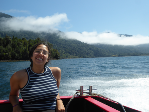

Ingeniera forestal, Universidad Mayor  
Valentina tiene interés en la biogeografía de plantas, especialmente las plantas vasculares alto andinas, y le gusta mucho la educación ambiental.

### Elias Encina, Asistente de Investigación

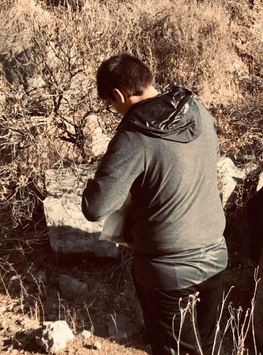

Geógrafo, Universidad de Chile  
Elias tiene interés principalmente en los insectos y quiere documentar su diversidad en Chile.

### Carla Quinteros, Coordinadora de Proyecto (ODES)

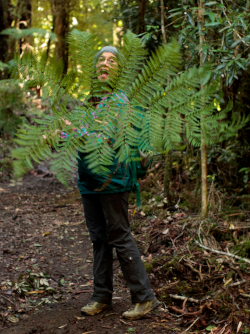

Arquitecta del Paisaje, Universidad de Chile

Carla se ha desempeñado en proyectos de restauración ecológica y de conservación, realizando trabajos vinculados a áreas naturales, Santuarios de la Naturaleza y especies vulnerables o en peligro de extinción. Su mayor motivación es el trabajo por la conservación de nuestros ecosistemas, su recuperación y protección.

### Carolina Córdova, Coordinadora logística

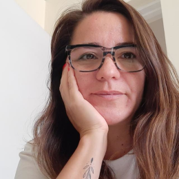

Ingeniera forestal y paisajista, Universidad de Chile  
Carolina lleva muchos sombreros en su vida profesional, entre ellos, tiene una [empresa de paisajismo](https://weinmannia.cl/), y es la persona que hace pequeños y grandes milagros presupuestarios y nos facilita nuestros proyectos.